# **Aquatic associated plant fungi across urbanization gradient**

Utah County, UT is one of the fastest growing regions of the United States. With increased population density, it is important to analyze the effects of urbanization on the surrounding environment and the organisms occupying it. Although the effects of urbanization on watersheds are well-studied, microbial communities are less so. Here, we utilized a watershed with increasing urbanization to examine the effects of human population, impermeable surface, and industrialization densities on the mycobiome of the aquatic plant, Ranunculus aquatilis. We used high-throughput amplicon sequencing of 16S and ITS regions to interrogate bacterial and fungal community composition. We hypothesize that increasing pollutant stress on plants will reduce microbial community diversity. Sequence data acquisition is ongoing at the time of this writing.

## **All taxonomy found along with absolute abundance**

[output not shown]

[output cut: 289 more lines]

## **Phylum relative abundance in each sample**

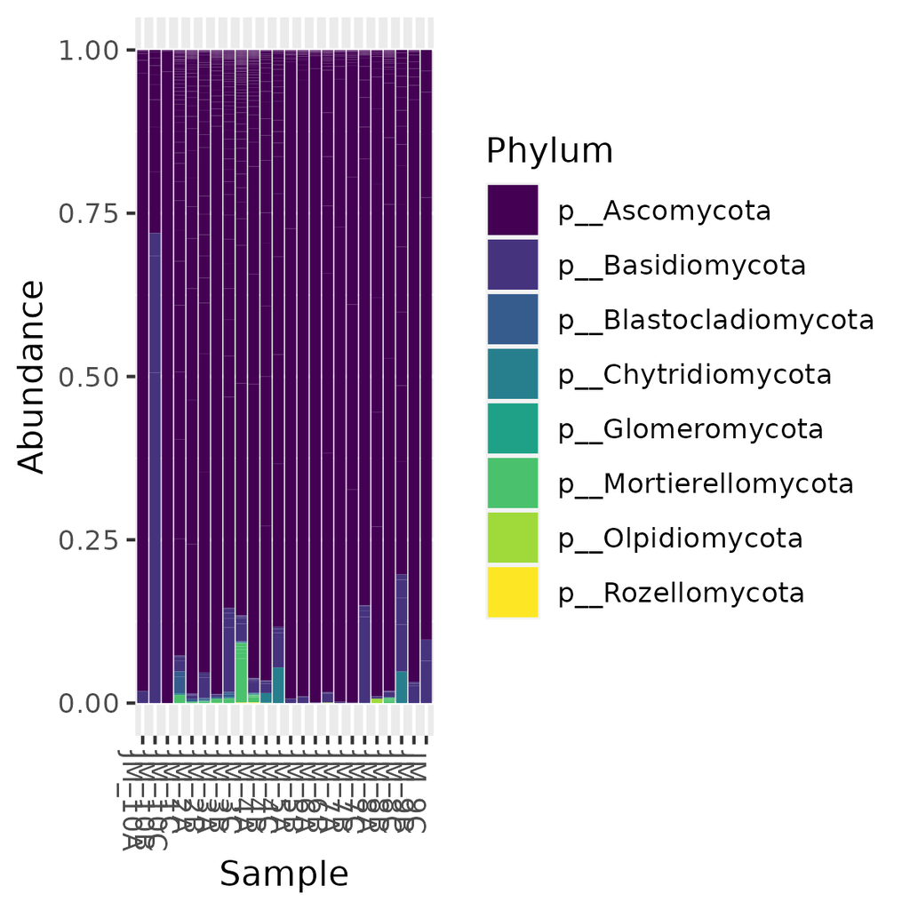

We can see a wide variety of fungal phyla but it was clearly dominated by ascomycetes.

## **Multiple regression on matrices**

| coef.asv_dist | coef.pval | r.squared | F.test |
| --- | --- | --- | --- |
| 0.8595583 | 0.839 | 0.0050603 | 1.393582 |
| 0.3894013 | 0.325 | 0.3250000 | 0.325000 |

## **Contact Us**

Jacob Mora | email: 10828799@uvu.edu Geoff Zahn | email: gzahn@uvu.edu